# Deep Learning for TS

Published

November 26, 2025

This section continues my project by integrating modern deep learning methods and comparing them with traditional time-series models. I’ll develop forecasting models, critically evaluate their performance, and reflect on how model choice influences forecasting accuracy and usefulness.

# Univariate Deep Learning Forecasting

**Recurrent Neural Network (RNN)**

```
Model: "sequential"
```

```
┏━━━━━━━━━━━━━━━━━━━━━━━━━━━━━━━━━┳━━━━━━━━━━━━━━━━━━━━━━━━┳━━━━━━━━━━━━━━━┓
┃ Layer (type)                    ┃ Output Shape           ┃       Param # ┃
┡━━━━━━━━━━━━━━━━━━━━━━━━━━━━━━━━━╇━━━━━━━━━━━━━━━━━━━━━━━━╇━━━━━━━━━━━━━━━┩
│ simple_rnn (SimpleRNN)          │ (None, 20)             │           440 │
├─────────────────────────────────┼────────────────────────┼───────────────┤
│ dropout (Dropout)               │ (None, 20)             │             0 │
├─────────────────────────────────┼────────────────────────┼───────────────┤
│ dense (Dense)                   │ (None, 1)              │            21 │
└─────────────────────────────────┴────────────────────────┴───────────────┘
```

```
 Total params: 461 (1.80 KB)
```

```
 Trainable params: 461 (1.80 KB)
```

```
 Non-trainable params: 0 (0.00 B)
```

```
None
=== RNN: Training history ===
```

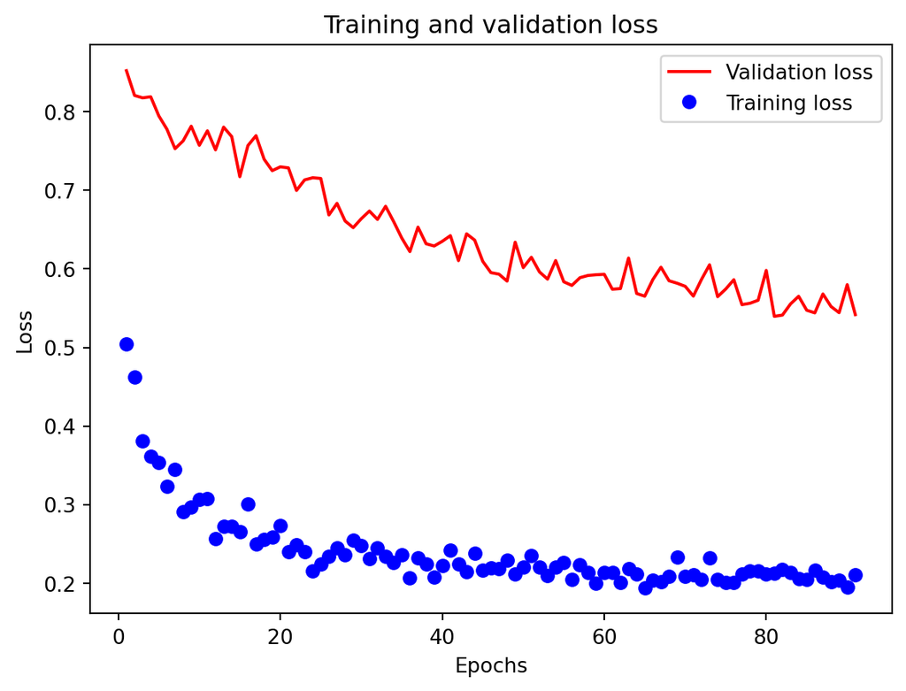

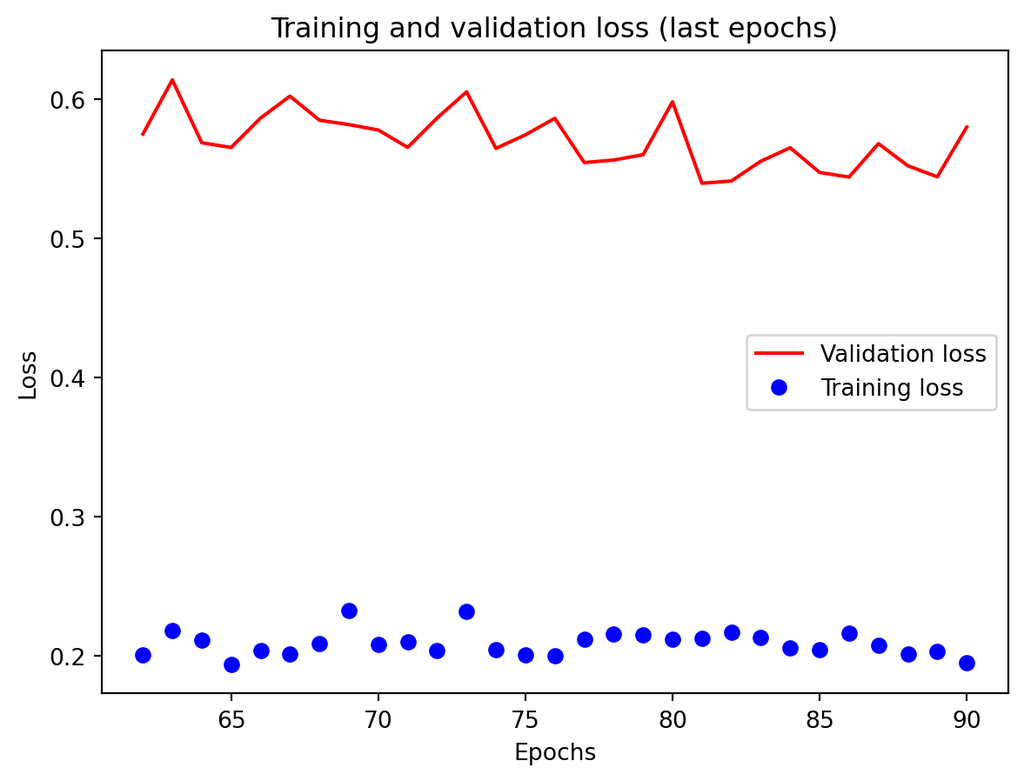

```
1/7 ━━━━━━━━━━━━━━━━━━━━ 0s 54ms/step7/7 ━━━━━━━━━━━━━━━━━━━━ 0s 9ms/step 7/7 ━━━━━━━━━━━━━━━━━━━━ 0s 10ms/step
1/2 ━━━━━━━━━━━━━━━━━━━━ 0s 6ms/step2/2 ━━━━━━━━━━━━━━━━━━━━ 0s 6ms/step
=== RNN results on Port of LA Total_TEUs ===
---------- Regression report ----------
TRAINING:
 MSE: 0.17548649017589774
 MAE: 0.3225873336076679
```

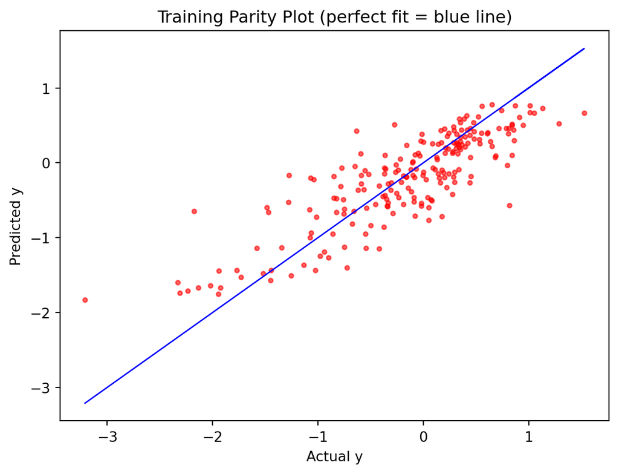

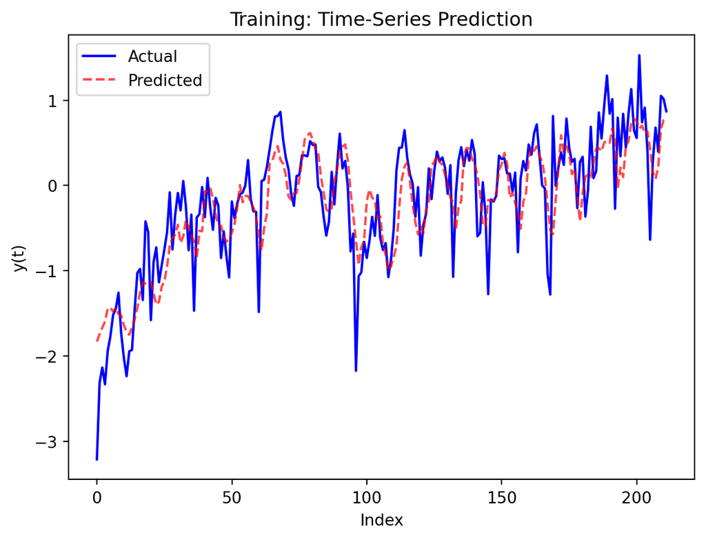

```
VALIDATION:
 MSE: 0.5319410484239163
 MAE: 0.5792183611105083
```

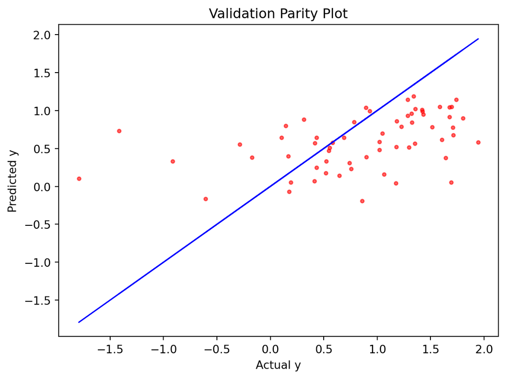

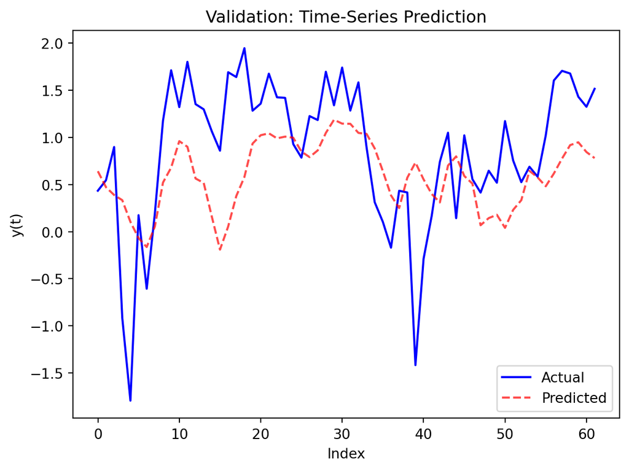

```
RNN Train RMSE: 0.4189110766927723
RNN Valid RMSE: 0.72934288810128
RNN RMSE (original scale): 119599.52 TEUs
```

```python
from tensorflow import keras
from tensorflow.keras import layers, regularizers
from keras.layers import Dense, SimpleRNN, LSTM, GRU, Dropout
from tensorflow.keras.callbacks import EarlyStopping
import numpy as np
from math import sqrt
from sklearn.metrics import mean_squared_error
import tensorflow as tf

import numpy as np
import random

tf.random.set_seed(42)
np.random.seed(42)


# ========= SHARED HYPERPARAMETERS =========
loss_function = "MeanSquaredError"
learning_rate = 0.001
numbers_epochs = 250
L1 = 1e-4
L2 = 1e-4
batch_size = 32
input_shape = (Xt.shape[1], Xt.shape[2])
recurrent_hidden_units = 32

# early stop to prevent overfitting
early_stop = EarlyStopping(
    monitor="val_loss",
    patience=10,
    restore_best_weights=True
)

def compute_rmse(y_true, y_pred):
    return sqrt(mean_squared_error(y_true, y_pred))


# SIMPLE RNN MODEL
model_rnn = keras.Sequential()
model_rnn.add(SimpleRNN(
    units=20,
    activation='tanh',
    input_shape=input_shape,
    recurrent_regularizer=regularizers.L1(L1),
    return_sequences=False
))
model_rnn.add(Dropout(0.2))
model_rnn.add(Dense(
    units=1,
    kernel_regularizer=regularizers.L1L2(l1=L1, l2=L2),
    activation="linear"
))

print(model_rnn.summary())

opt = keras.optimizers.RMSprop(learning_rate=learning_rate)
model_rnn.compile(optimizer=opt, loss=loss_function)

history_rnn = model_rnn.fit(
    Xt,
    Yt,
    epochs=numbers_epochs,
    batch_size=batch_size,
    verbose=False,
    validation_data=(Xv, Yv),
    callbacks=[early_stop],
)

print("=== RNN: Training history ===")
history_plot(history_rnn)

Ytp_rnn = model_rnn.predict(Xt)
Yvp_rnn = model_rnn.predict(Xv)

print("=== RNN results on Port of LA Total_TEUs ===")
regression_report(Yt, Ytp_rnn, Yv, Yvp_rnn)
print("RNN Train RMSE:", compute_rmse(Yt, Ytp_rnn))
print("RNN Valid RMSE:", compute_rmse(Yv, Yvp_rnn))

Yvp_rnn_original = Yvp_rnn * x_std + x_mean
Yvp_rnn_original = np.exp(Yvp_rnn_original)

# 然后计算原始尺度的 RMSE
rmse_rnn_original = np.sqrt(mean_squared_error(
    np.exp(Yv * x_std + x_mean),
    Yvp_rnn_original
))
print(f"RNN RMSE (original scale): {rmse_rnn_original:.2f} TEUs")
```

**Gated Recurrent Unit (GRU)**

```
=== GRU: Training history ===
```

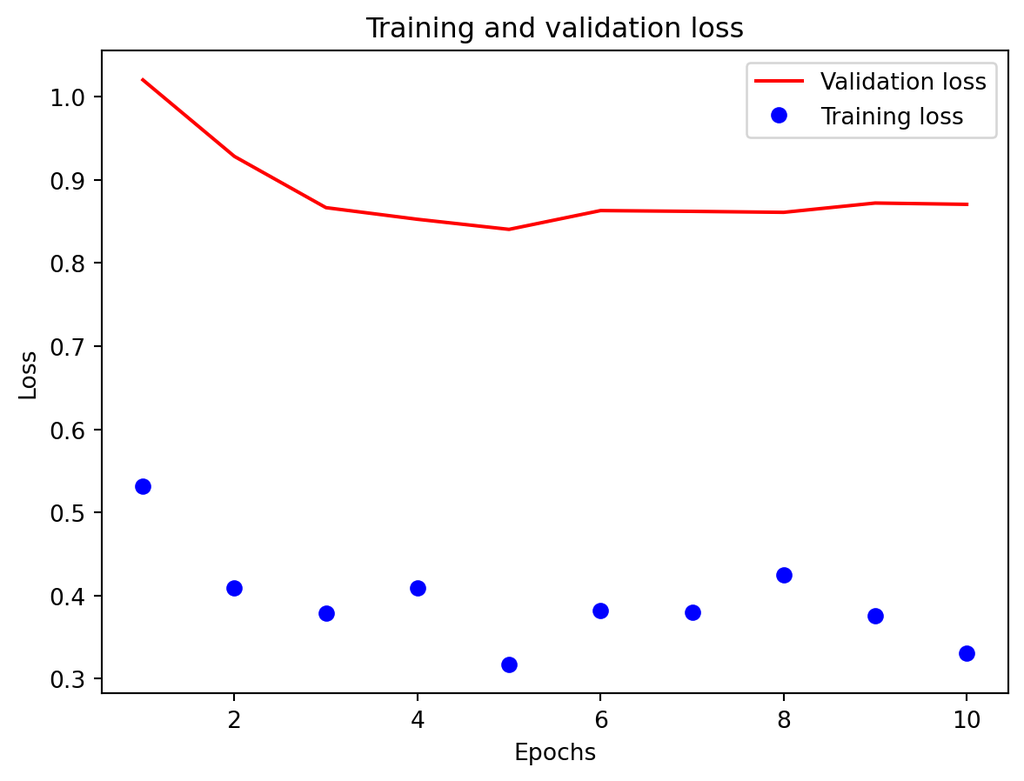

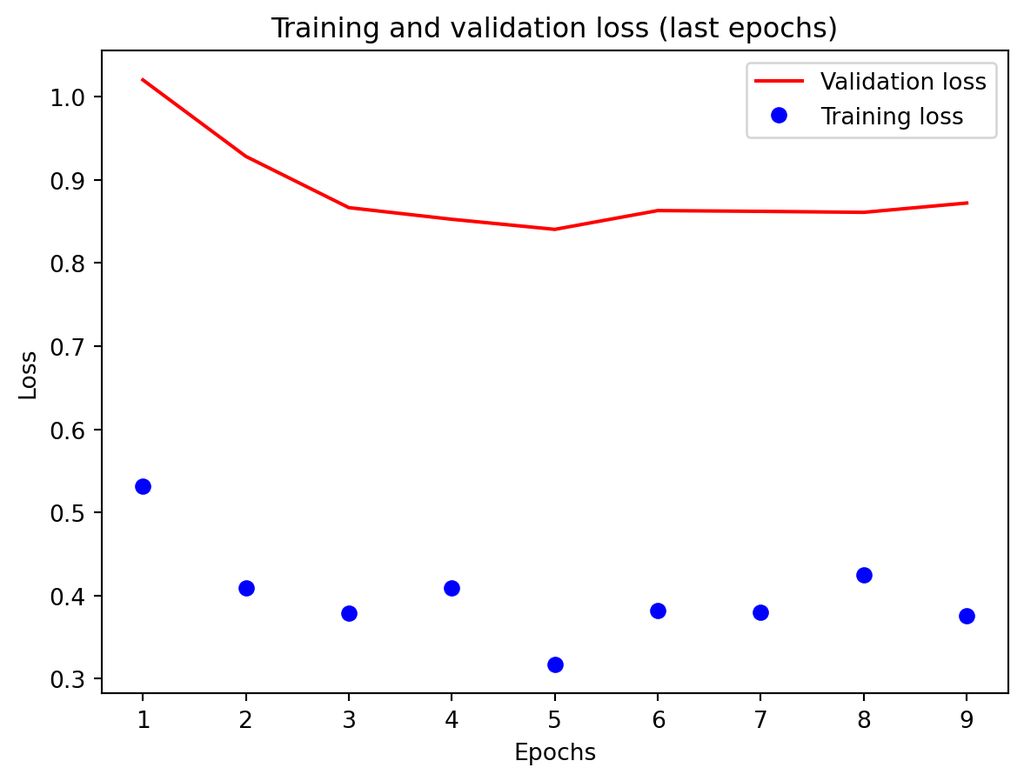

```
1/7 ━━━━━━━━━━━━━━━━━━━━ 1s 181ms/step7/7 ━━━━━━━━━━━━━━━━━━━━ 0s 30ms/step 7/7 ━━━━━━━━━━━━━━━━━━━━ 0s 30ms/step
1/2 ━━━━━━━━━━━━━━━━━━━━ 0s 7ms/step2/2 ━━━━━━━━━━━━━━━━━━━━ 0s 6ms/step
=== GRU results on Port of LA Total_TEUs ===
---------- Regression report ----------
TRAINING:
 MSE: 0.3769720318228817
 MAE: 0.4681205627286687
```

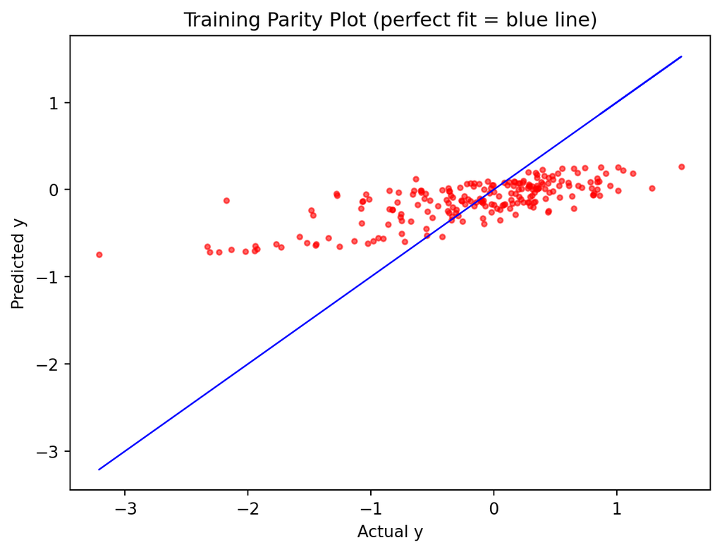

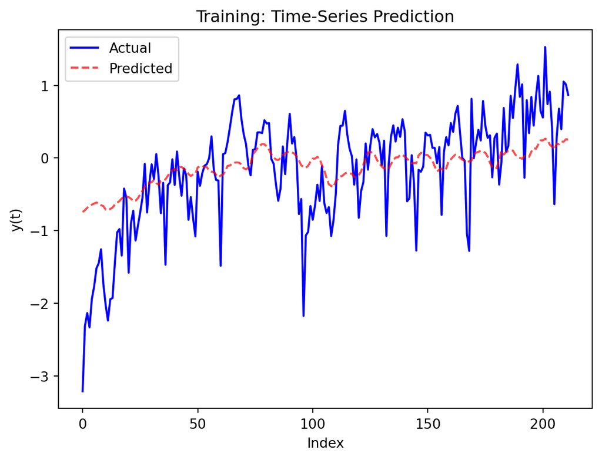

```
VALIDATION:
 MSE: 1.0182768299154232
 MAE: 0.8748787498090888
```

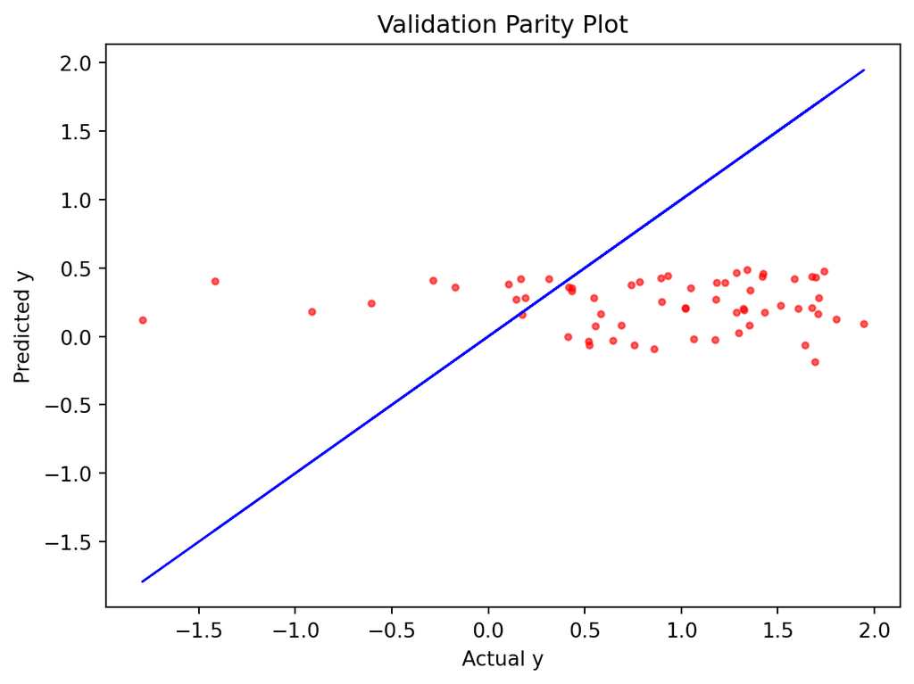

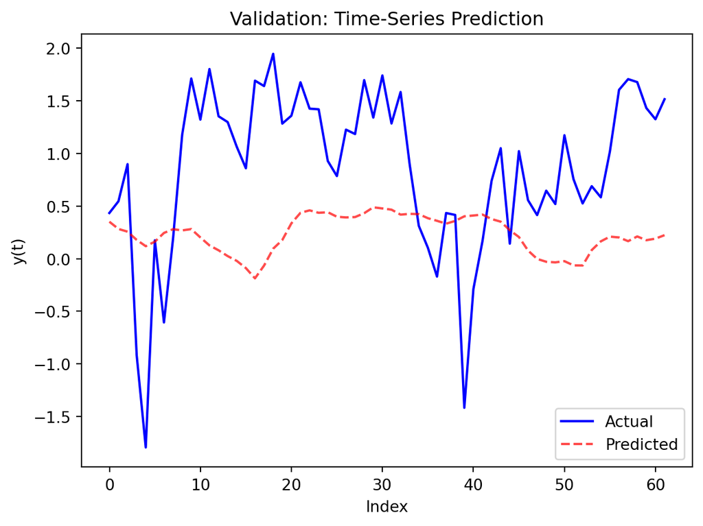

```
GRU Train RMSE: 0.6139804816302239
GRU Valid RMSE: 1.0090970369173735
GRU RMSE (original scale): 168299.72 TEUs
```

```python
from tensorflow.keras.layers import GRU, Dropout, Dense
from tensorflow import keras
from tensorflow.keras import regularizers
import numpy as np
import random
import tensorflow as tf

tf.random.set_seed(42)
np.random.seed(42)

model_gru = keras.Sequential()

model_gru.add(GRU(
    units=16,
    activation='tanh',
    recurrent_dropout=0.2,
    dropout=0.2,
    input_shape=input_shape,
    recurrent_regularizer=regularizers.L2(1e-4),
    return_sequences=False
))

model_gru.add(Dropout(0.3))

model_gru.add(Dense(
    units=1,
    kernel_regularizer=regularizers.L2(1e-4),
    activation='linear'
))

opt_gru = keras.optimizers.Adam(learning_rate=0.001)
model_gru.compile(optimizer=opt_gru, loss="mse")

history_gru = model_gru.fit(
    Xt, Yt,
    epochs=200,
    batch_size=8,
    verbose=False,
    validation_data=(Xv, Yv),
    callbacks=[early_stop],
)

print("=== GRU: Training history ===")
history_plot(history_gru)

Ytp = model_gru.predict(Xt)
Yvp = model_gru.predict(Xv)

print("=== GRU results on Port of LA Total_TEUs ===")
regression_report(Yt, Ytp, Yv, Yvp)

from sklearn.metrics import mean_squared_error

gru_train_rmse = np.sqrt(mean_squared_error(Yt, Ytp))
gru_valid_rmse = np.sqrt(mean_squared_error(Yv, Yvp))

print("GRU Train RMSE:", gru_train_rmse)
print("GRU Valid RMSE:", gru_valid_rmse)

Yvp_gru_original = Yvp * x_std + x_mean
Yvp_gru_original = np.exp(Yvp_gru_original)

Yv_original = np.exp(Yv * x_std + x_mean)

rmse_gru_original = np.sqrt(mean_squared_error(Yv_original, Yvp_gru_original))
print(f"GRU RMSE (original scale): {rmse_gru_original:.2f} TEUs")
```

**Long Short-Term Memory (LSTM)**

```
=== LSTM: Training history ===
```

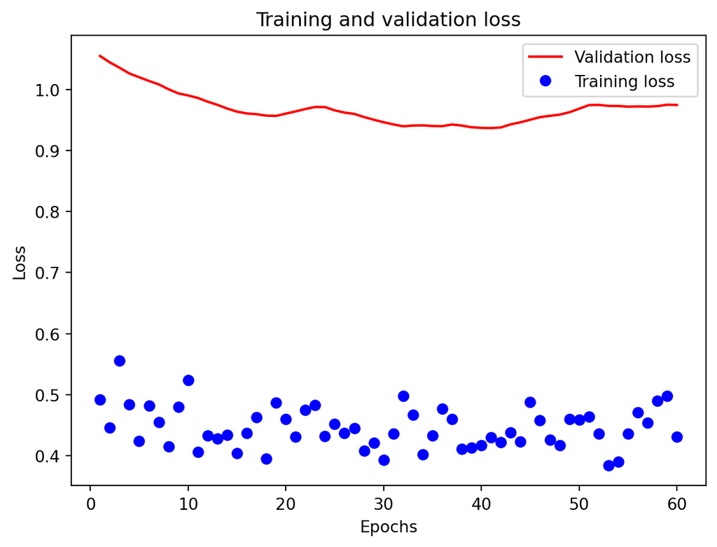

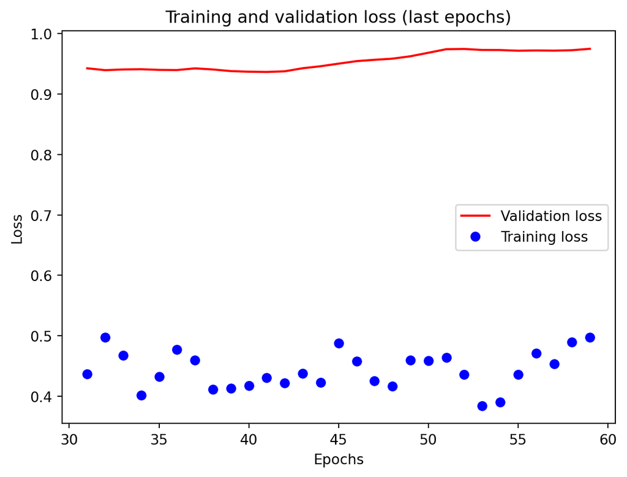

```
1/7 ━━━━━━━━━━━━━━━━━━━━ 0s 158ms/step7/7 ━━━━━━━━━━━━━━━━━━━━ 0s 26ms/step 7/7 ━━━━━━━━━━━━━━━━━━━━ 0s 27ms/step
1/2 ━━━━━━━━━━━━━━━━━━━━ 0s 6ms/step2/2 ━━━━━━━━━━━━━━━━━━━━ 0s 6ms/step
=== LSTM results on Port of LA Total_TEUs ===
---------- Regression report ----------
TRAINING:
 MSE: 0.286462108778718
 MAE: 0.4166779271728177
```

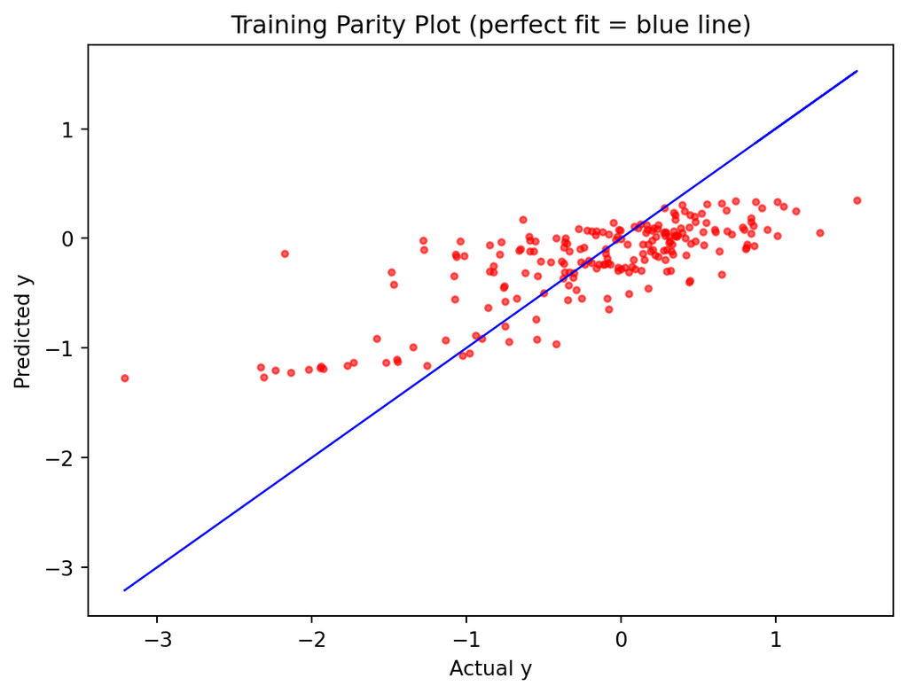

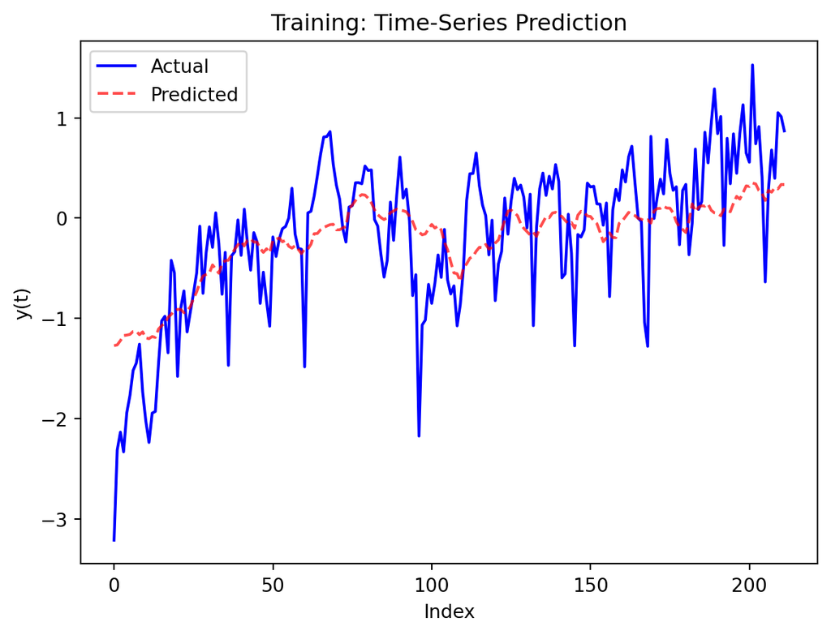

```
VALIDATION:
 MSE: 0.9260795458038847
 MAE: 0.8277720933511526
```

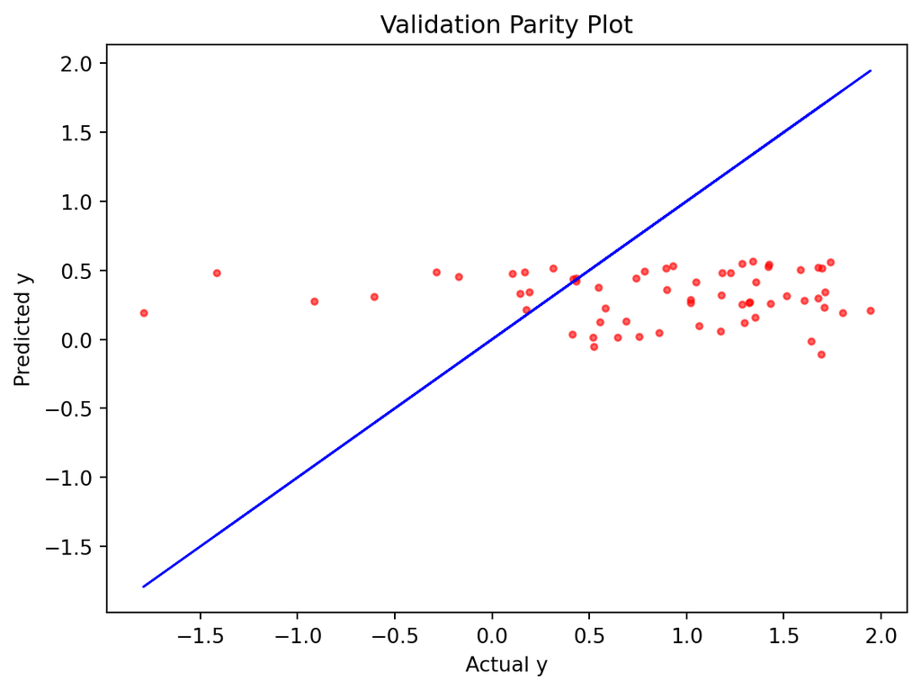

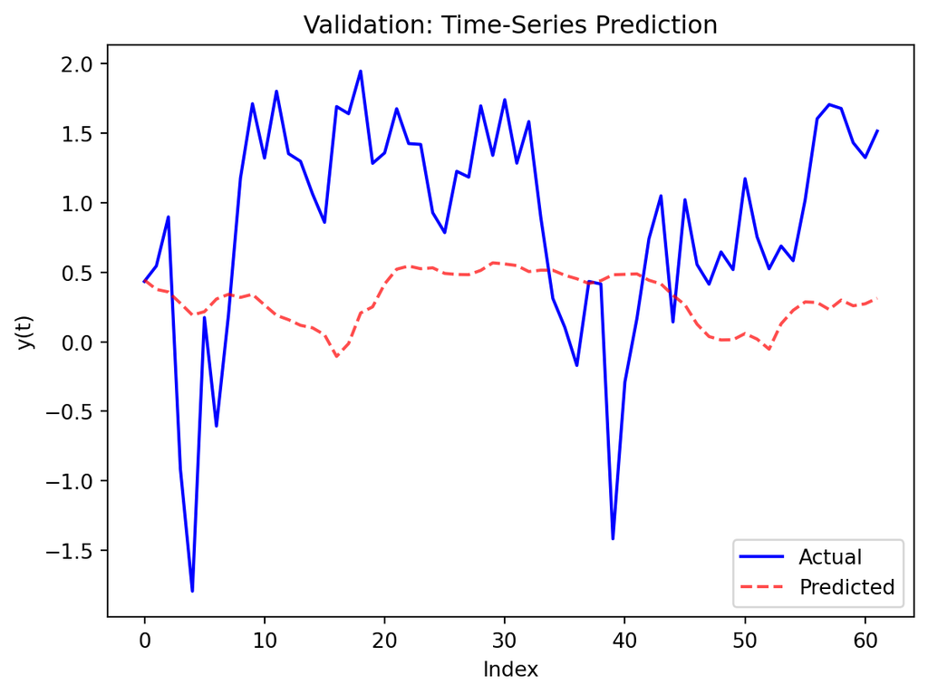

```
LSTM Train RMSE: 0.5352215511157207
LSTM Validation RMSE: 0.9623302685688967
LSTM RMSE (original scale): 168299.72 TEUs
```

```python
from tensorflow.keras.layers import LSTM, Dense
from tensorflow import keras
import numpy as np
import tensorflow as tf

tf.random.set_seed(42)
np.random.seed(42)

model_lstm = keras.Sequential()

model_lstm.add(LSTM(
    units=12,
    activation='tanh',
    recurrent_activation='sigmoid',
    recurrent_dropout=0.25,
    dropout=0.35,
    input_shape=input_shape,
    recurrent_regularizer=regularizers.L1L2(l1=1e-4, l2=1e-4),
    kernel_regularizer=regularizers.L1L2(l1=1e-4, l2=1e-4),
    return_sequences=False
))

model_lstm.add(Dropout(0.4))

model_lstm.add(Dense(
    units=1,
    kernel_regularizer=regularizers.L2(1e-3),  #1e-4 → 1e-3
    activation='linear'
))

opt_lstm = keras.optimizers.Adam(learning_rate=0.0003)  # 0.001 → 0.0003

model_lstm.compile(optimizer=opt_lstm, loss='mse')

early_stop_strict = EarlyStopping(
    monitor="val_loss",
    patience=20,
    restore_best_weights=True,
    min_delta=0.005
)

history_lstm = model_lstm.fit(
    Xt, Yt,
    epochs=300,
    batch_size=32,
    verbose=False,
    validation_data=(Xv, Yv),
    callbacks=[early_stop_strict],
)

print("=== LSTM: Training history ===")
history_plot(history_lstm)

# Predictions
Ytp_lstm = model_lstm.predict(Xt)
Yvp_lstm = model_lstm.predict(Xv)

print("=== LSTM results on Port of LA Total_TEUs ===")
regression_report(Yt, Ytp_lstm, Yv, Yvp_lstm)

# RMSE
lstm_train_rmse = np.sqrt(mean_squared_error(Yt, Ytp_lstm))
lstm_valid_rmse = np.sqrt(mean_squared_error(Yv, Yvp_lstm))
print("LSTM Train RMSE:", lstm_train_rmse)
print("LSTM Validation RMSE:", lstm_valid_rmse)
Yvp_lstm_original = Yvp * x_std + x_mean
Yvp_lstm_original = np.exp(Yvp_lstm_original)

Yv_original = np.exp(Yv * x_std + x_mean)

rmse_lstm_original = np.sqrt(mean_squared_error(Yv_original, Yvp_lstm_original))
print(f"LSTM RMSE (original scale): {rmse_lstm_original:.2f} TEUs")
```

### Analysis

#### 1. Relative Performance

In terms of forecast behavior, the RNN is better able to follow the general upward trend and moderate fluctuations visible in the TEU series. GRU and LSTM, by contrast, tend to collapse toward the mean and fail to capture short-term variations, leading to flatter predicted curves and weaker correlation in the parity plots. These results suggest that for this relatively small dataset, simpler models generalize better than more complex gated architectures.

#### 2. Effectiveness of Regularization

However, stronger regularization (especially in GRU/LSTM) often caused underfitting, flattening their predictions and shrinking their variance. This is a common issue when gated recurrent units are applied to small datasets: excessive regularization overwhelms the model’s capacity and leads to overly conservative predictions.

Overall, regularization improved training stability, but heavy regularization hurt the GRU/LSTM more than the RNN due to the dataset’s small size.

#### 3. Forecast Horizon

Based on the validation time-series plots, all three models show similar forecast limits.

- **Short-term (1–3 steps ahead):**

RNN predictions generally follow the direction of movement.

GRU and LSTM partially capture near-term changes but remain conservative.

- **Medium-term (3–6 steps ahead):**

All models begin to drift toward the mean.

Peaks and troughs are not accurately captured.

- **Long-term (>6 steps ahead):**

Models lose the seasonal and cyclical structure.

Predictions flatten significantly, especially in GRU/LSTM.

This indicates that these deep learning models are effective for short-horizon forecasting, but their ability to capture longer seasonal dynamics is limited when trained on a relatively small monthly dataset.

#### 4. Comparison with Traditional ARMA/ARIMA Models

Compared with the ARIMA model from Homework 3, the deep learning models display different strengths and weaknesses.

- Deep learning models capture nonlinear short-term patterns better but fail to reproduce seasonal cycles due to limited data size and the lack of explicit seasonality structure.
- ARIMA models explicitly model monthly seasonality and cumulative trends, giving them a structural advantage for long-horizon forecasting.
- Deep learning models show higher variance in results, are more sensitive to hyperparameters, and require much larger datasets to outperform classical models.

Overall, for this dataset, ARIMA remains the superior model for long-term and seasonal forecasting, while RNN is the strongest deep learning model for short-term movement prediction, though still inferior to SARIMA in stability and accuracy.

# Forecasting Performance Reflection

The comparison taught me that forecasting is ultimately about matching the model to the structure of the data. For a dataset with a clear trend, strong seasonality, and limited sample size, a well-specified classical model can outperform more sophisticated neural networks. Deep learning remains valuable when incorporating richer exogenous factors or nonlinear behaviors, but for this univariate TEU series, SARIMA is the most appropriate tool.

# Multivariate Forecasting – Deep Learning vs Traditional Models

**Recurrent Neural Network (RNN)**

```
---------- Multivariate Data setup ----------
training: (96, 17, 2) (96, 1)
validation: (21, 17, 2) (21, 1)
```

```
=== Multivariate RNN: Training history ===
```

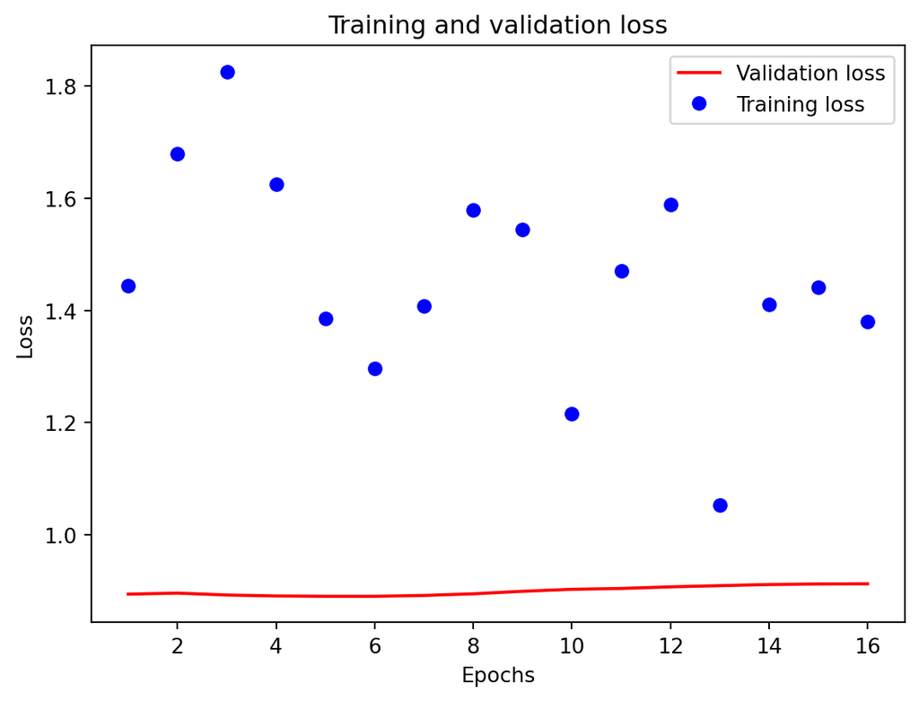

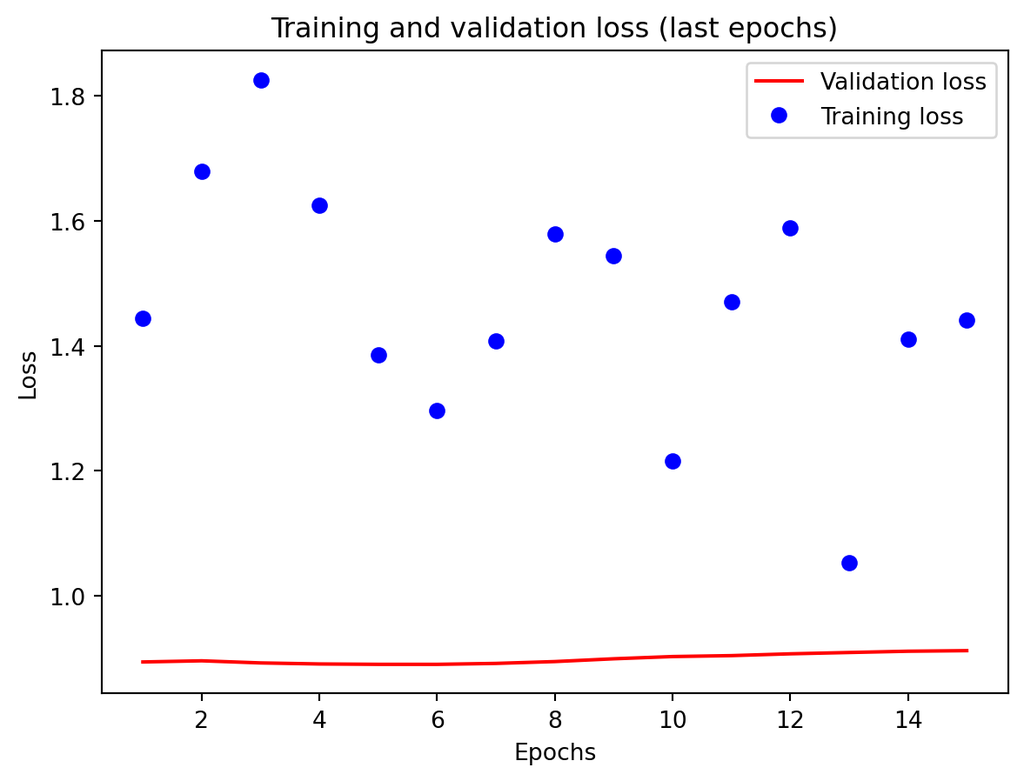

```
1/3 ━━━━━━━━━━━━━━━━━━━━ 0s 77ms/step3/3 ━━━━━━━━━━━━━━━━━━━━ 0s 3ms/step
1/1 ━━━━━━━━━━━━━━━━━━━━ 0s 76ms/step1/1 ━━━━━━━━━━━━━━━━━━━━ 0s 81ms/step
=== Multivariate RNN results on Port of LA Total_TEUs ===
---------- Regression report ----------
TRAINING:
 MSE: 0.8544798265843078
 MAE: 0.7313539250757115
```

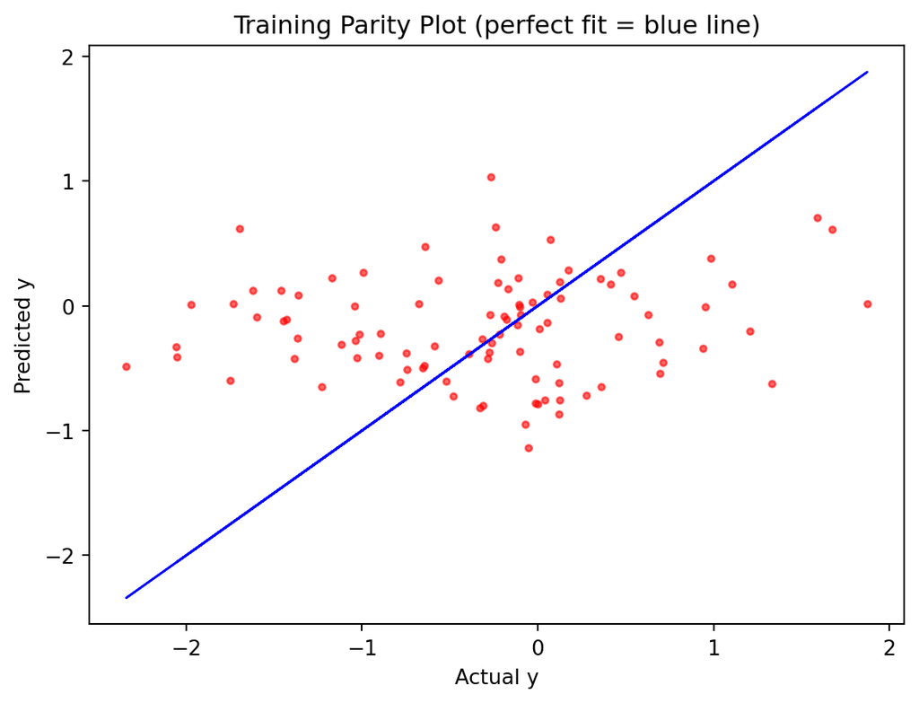

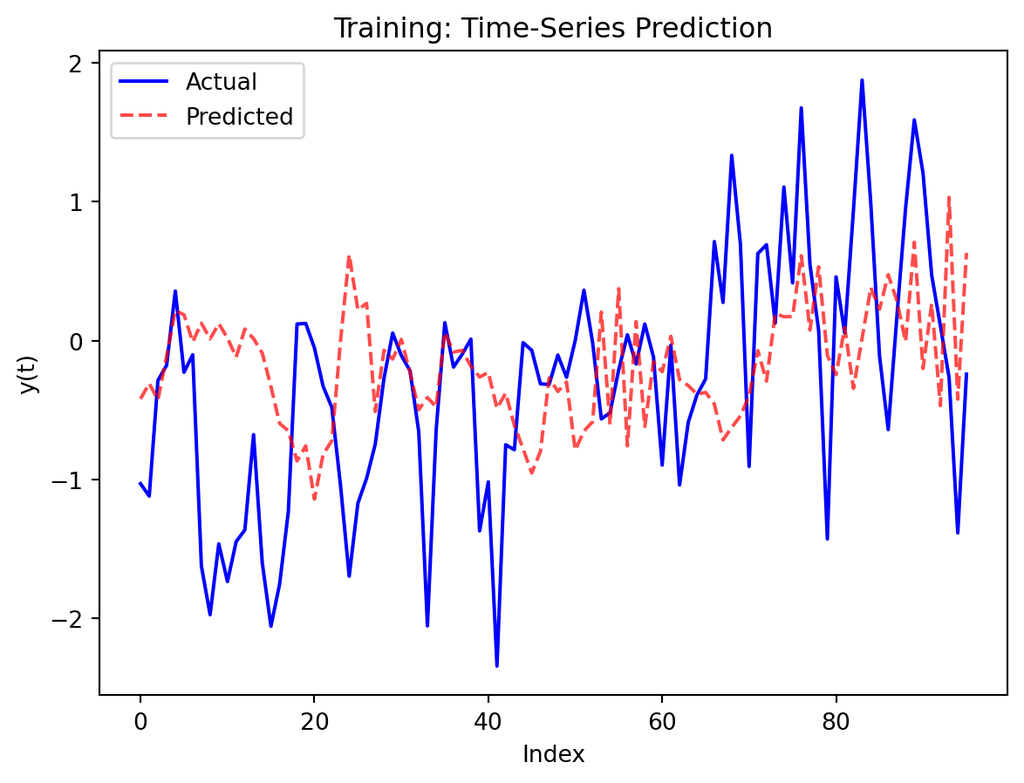

```
VALIDATION:
 MSE: 0.882557109307875
 MAE: 0.7341999392034666
```

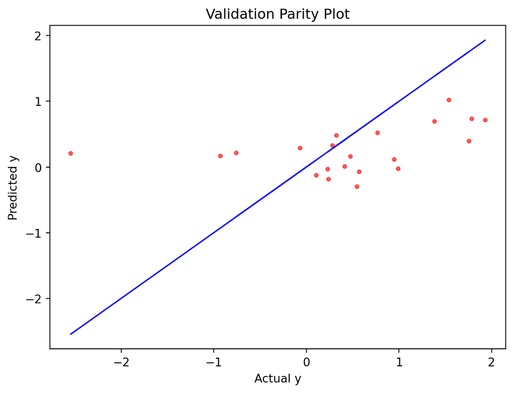

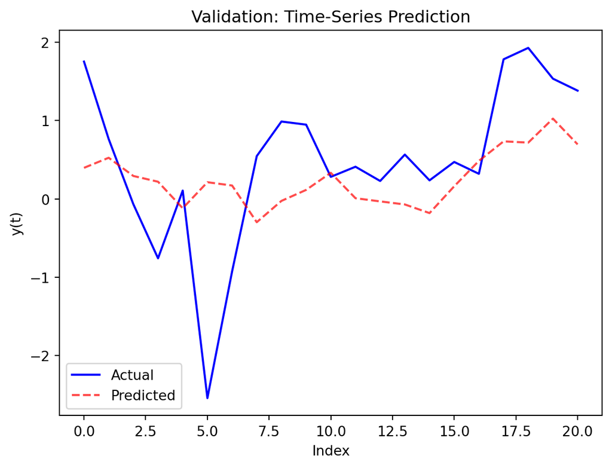

```
Multivariate RNN Train RMSE: 0.9243807800816218
Multivariate RNN Valid RMSE: 0.9394451071286044
Multivariate RNN RMSE (original scale): 138693.19 TEUs
```

```python
feature_columns = [0, 2]
target_columns  = [3]

L = 16
S = 1
D = 1

Xt, Yt = form_arrays(
    xt,
    lookback=L,
    delay=D,
    step=S,
    feature_columns=feature_columns,
    target_columns=target_columns,
    unique=False,
    verbose=False,
)

Xv, Yv = form_arrays(
    xv,
    lookback=L,
    delay=D,
    step=S,
    feature_columns=feature_columns,
    target_columns=target_columns,
    unique=False,
    verbose=False,
)

print("---------- Multivariate Data setup ----------")
print("training:", Xt.shape, Yt.shape)
print("validation:", Xv.shape, Yv.shape)

def compute_rmse(y_true, y_pred):
    y_true = np.array(y_true).reshape(-1)
    y_pred = np.array(y_pred).reshape(-1)
    return sqrt(mean_squared_error(y_true, y_pred))

def regression_report(yt, ytp, yv, yvp):
    yt  = np.array(yt).reshape(-1)
    ytp = np.array(ytp).reshape(-1)
    yv  = np.array(yv).reshape(-1)
    yvp = np.array(yvp).reshape(-1)

    print("---------- Regression report ----------")

    # TRAINING METRICS
    print("TRAINING:")
    print(" MSE:", mean_squared_error(yt, ytp))
    print(" MAE:", mean_absolute_error(yt, ytp))

    # Training parity plot
    fig, ax = plt.subplots()
    ax.plot(yt, ytp, "ro", markersize=3, alpha=0.6)
    ax.plot(yt, yt, "b-", linewidth=1)
    ax.set(
        xlabel="Actual y",
        ylabel="Predicted y",
        title="Training Parity Plot (perfect fit = blue line)",
    )
    plt.show()

    # Training time-series plot
    fig, ax = plt.subplots()
    ax.plot(yt, "b-", label="Actual")
    ax.plot(ytp, "r--", label="Predicted", alpha=0.7)
    ax.legend()
    ax.set(
        xlabel="Index",
        ylabel="y(t)",
        title="Training: Time-Series Prediction",
    )
    plt.show()

    # VALIDATION METRICS
    print("VALIDATION:")
    print(" MSE:", mean_squared_error(yv, yvp))
    print(" MAE:", mean_absolute_error(yv, yvp))

    # Validation parity plot
    fig, ax = plt.subplots()
    ax.plot(yv, yvp, "ro", markersize=3, alpha=0.6)
    ax.plot(yv, yv, "b-", linewidth=1)
    ax.set(
        xlabel="Actual y",
        ylabel="Predicted y",
        title="Validation Parity Plot",
    )
    plt.show()

    # Validation time-series
    fig, ax = plt.subplots()
    ax.plot(yv, "b-", label="Actual")
    ax.plot(yvp, "r--", label="Predicted", alpha=0.7)
    ax.legend()
    ax.set(
        xlabel="Index",
        ylabel="y(t)",
        title="Validation: Time-Series Prediction",
    )
    plt.show()

loss_function = "MeanSquaredError"
learning_rate = 0.001
numbers_epochs = 250
L1 = 1e-4
L2 = 1e-4
batch_size = 32
input_shape = (Xt.shape[1], Xt.shape[2])   # (12, 2)
recurrent_hidden_units = 32

early_stop = EarlyStopping(
    monitor="val_loss",
    patience=10,
    restore_best_weights=True
)

model_rnn_multi = keras.Sequential()
model_rnn_multi.add(SimpleRNN(
    units=20,
    activation='tanh',
    input_shape=input_shape,
    dropout=0.3,
    recurrent_dropout=0.3,
    recurrent_regularizer=regularizers.L2(5e-4),
    return_sequences=False
))
model_rnn_multi.add(Dropout(0.4))
model_rnn_multi.add(Dense(
    units=1,
    kernel_regularizer=regularizers.L2(5e-4),
    activation="linear"
))

opt = keras.optimizers.Adam(learning_rate=0.0005)
model_rnn_multi.compile(optimizer=opt, loss='mse')

early_stop_strict = EarlyStopping(
    monitor="val_loss",
    patience=15,  # 10 → 15
    restore_best_weights=True,
    min_delta=0.005
)

history_rnn_multi = model_rnn_multi.fit(
    Xt, Yt,
    epochs=300,
    batch_size=32,
    verbose=0,
    validation_data=(Xv, Yv),
    callbacks=[early_stop_strict],
)

print("=== Multivariate RNN: Training history ===")
history_plot(history_rnn_multi)

Ytp_rnn_multi = model_rnn_multi.predict(Xt)
Yvp_rnn_multi = model_rnn_multi.predict(Xv)

print("=== Multivariate RNN results on Port of LA Total_TEUs ===")
regression_report(Yt, Ytp_rnn_multi, Yv, Yvp_rnn_multi)
print("Multivariate RNN Train RMSE:", compute_rmse(Yt, Ytp_rnn_multi))
print("Multivariate RNN Valid RMSE:", compute_rmse(Yv, Yvp_rnn_multi))


Yvp_rnn_multi_original = np.exp((Yvp_rnn_multi.reshape(-1) * x_std) + x_mean)

Yv_original = np.exp((Yv.reshape(-1) * x_std) + x_mean)

rmse_rnn_multi_original = np.sqrt(mean_squared_error(Yv_original, Yvp_rnn_multi_original))
print(f"Multivariate RNN RMSE (original scale): {rmse_rnn_multi_original:.2f} TEUs")
```

**GRU**

```
Model: "sequential_4"
```

```
┏━━━━━━━━━━━━━━━━━━━━━━━━━━━━━━━━━┳━━━━━━━━━━━━━━━━━━━━━━━━┳━━━━━━━━━━━━━━━┓
┃ Layer (type)                    ┃ Output Shape           ┃       Param # ┃
┡━━━━━━━━━━━━━━━━━━━━━━━━━━━━━━━━━╇━━━━━━━━━━━━━━━━━━━━━━━━╇━━━━━━━━━━━━━━━┩
│ gru_1 (GRU)                     │ (None, 16)             │           960 │
├─────────────────────────────────┼────────────────────────┼───────────────┤
│ dropout_4 (Dropout)             │ (None, 16)             │             0 │
├─────────────────────────────────┼────────────────────────┼───────────────┤
│ dense_4 (Dense)                 │ (None, 1)              │            17 │
└─────────────────────────────────┴────────────────────────┴───────────────┘
```

```
 Total params: 977 (3.82 KB)
```

```
 Trainable params: 977 (3.82 KB)
```

```
 Non-trainable params: 0 (0.00 B)
```

```
None
=== Multivariate GRU: Training history ===
```

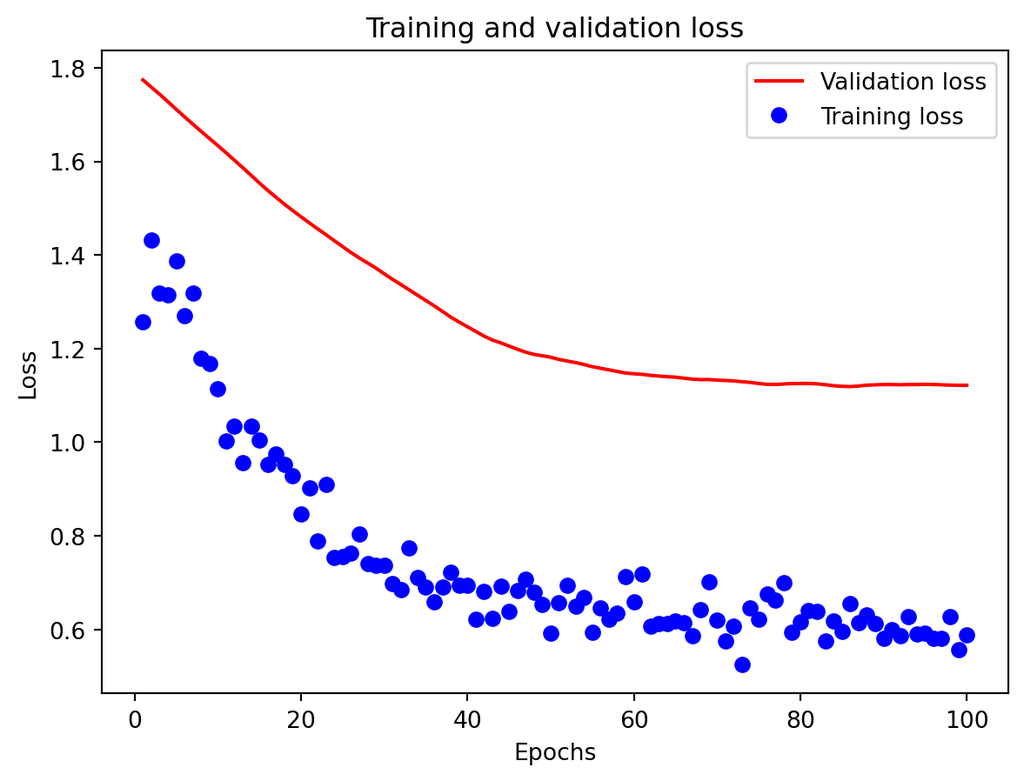

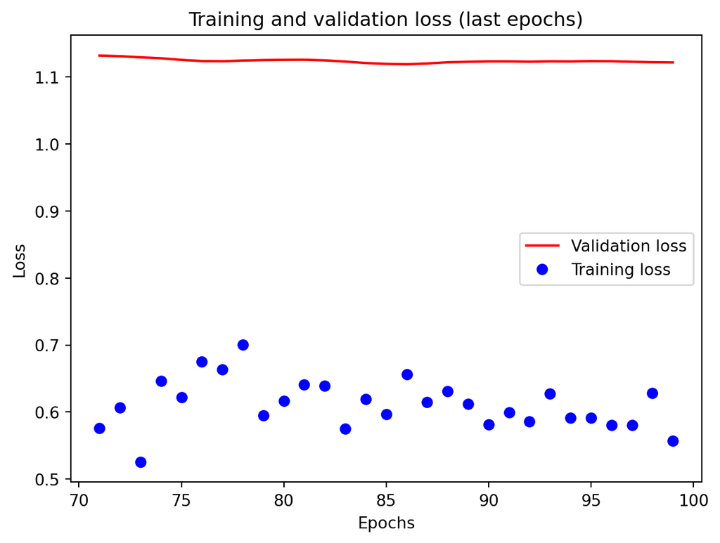

```
WARNING:tensorflow:5 out of the last 14 calls to <function TensorFlowTrainer.make_predict_function.<locals>.one_step_on_data_distributed at 0x168805b40> triggered tf.function retracing. Tracing is expensive and the excessive number of tracings could be due to (1) creating @tf.function repeatedly in …
1/3 ━━━━━━━━━━━━━━━━━━━━ 0s 163ms/step3/3 ━━━━━━━━━━━━━━━━━━━━ 0s 3ms/step
WARNING:tensorflow:5 out of the last 11 calls to <function TensorFlowTrainer.make_predict_function.<locals>.one_step_on_data_distributed at 0x168805b40> triggered tf.function retracing. Tracing is expensive and the excessive number of tracings could be due to (1) creating @tf.function repeatedly in …
1/1 ━━━━━━━━━━━━━━━━━━━━ 0s 164ms/step1/1 ━━━━━━━━━━━━━━━━━━━━ 0s 170ms/step
=== Multivariate GRU results on Port of LA Total_TEUs ===
---------- Regression report ----------
TRAINING:
 MSE: 0.5274813907008472
 MAE: 0.5815626837500545
```

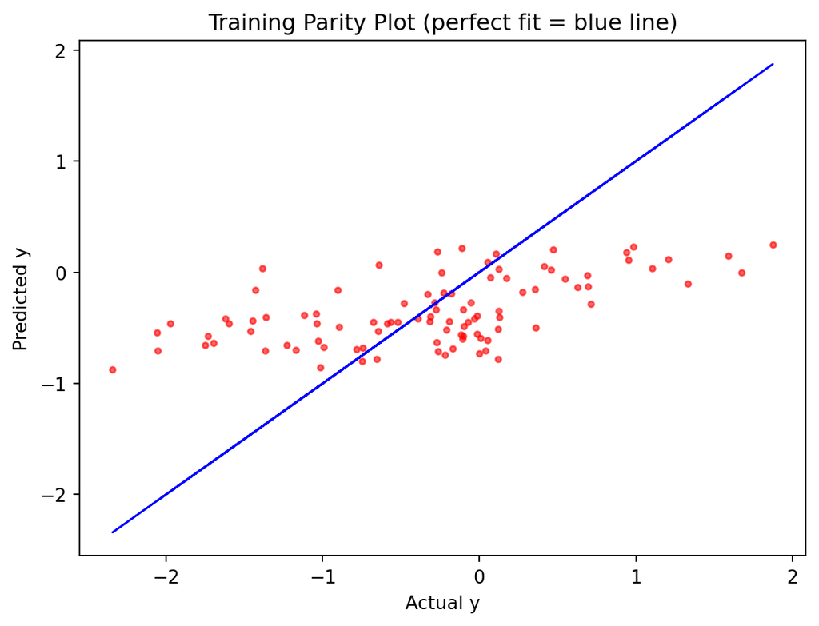

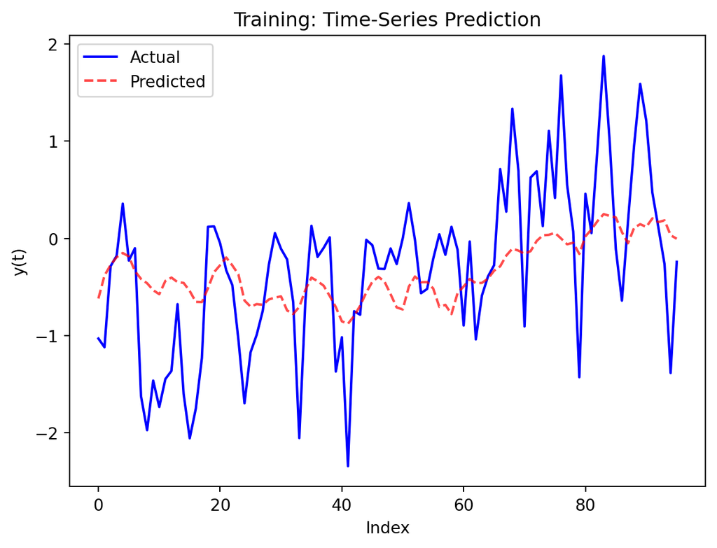

```
VALIDATION:
 MSE: 1.1114338525381537
 MAE: 0.7512106374699631
```

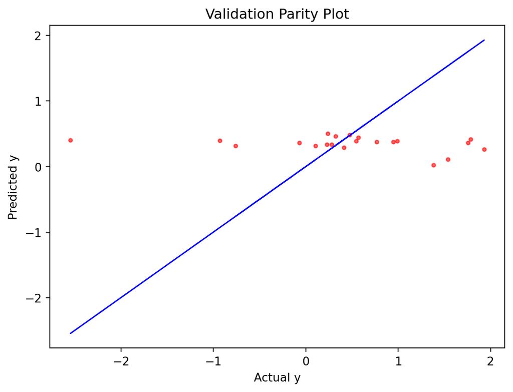

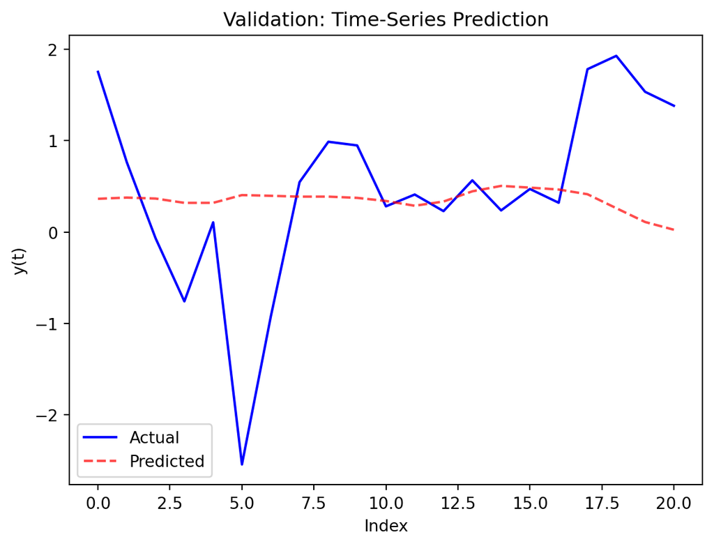

```
Multivariate GRU Train RMSE: 0.7262791410338364
Multivariate GRU Valid RMSE: 1.0542456319748987
Multivariate GRU RMSE (original scale): 160109.17 TEUs
```

```python
# ========================================
# MULTIVARIATE GRU MODEL
# ========================================

import tensorflow as tf
import numpy as np
from tensorflow import keras
from tensorflow.keras.layers import GRU, Dense, Dropout
from tensorflow.keras import regularizers
from tensorflow.keras.callbacks import EarlyStopping
from sklearn.metrics import mean_squared_error
from math import sqrt

# Set random seeds for reproducibility
tf.random.set_seed(42)
np.random.seed(42)

# ========= HYPERPARAMETERS =========
loss_function = "MeanSquaredError"
learning_rate = 0.0005
numbers_epochs = 300
L1 = 1e-4
L2 = 1e-4
batch_size = 32
input_shape = (Xt.shape[1], Xt.shape[2])   # (12, 2) for lookback=12, features=2
recurrent_hidden_units = 16  # Smaller for multivariate to prevent overfitting

# Early stopping callback
early_stop = EarlyStopping(
    monitor="val_loss",
    patience=15,
    restore_best_weights=True,
    min_delta=0.003
)

# ========= CREATE MODEL =========
model_gru_multi = keras.Sequential()

# ADD RECURRENT LAYER
model_gru_multi.add(GRU(
    units=recurrent_hidden_units,
    activation='tanh',  # tanh often more stable than relu for small datasets
    input_shape=input_shape,
    dropout=0.3,
    recurrent_dropout=0.3,
    recurrent_regularizer=regularizers.L2(5e-4),  # L2 for multivariate
    return_sequences=False
))

model_gru_multi.add(Dropout(0.35))

model_gru_multi.add(Dense(
    units=1,
    kernel_regularizer=regularizers.L2(5e-4),
    activation='linear'
))

# MODEL SUMMARY
print(model_gru_multi.summary())

# ========= COMPILING THE MODEL =========
opt = keras.optimizers.Adam(learning_rate=learning_rate, clipnorm=1.0)
model_gru_multi.compile(optimizer=opt, loss=loss_function)

# ========= TRAINING YOUR MODEL =========
history_gru_multi = model_gru_multi.fit(
    Xt,
    Yt,
    epochs=numbers_epochs,
    batch_size=batch_size,
    verbose=False,
    validation_data=(Xv, Yv),
    callbacks=[early_stop],
)

# ========= History plot =========
print("=== Multivariate GRU: Training history ===")
history_plot(history_gru_multi)

# ========= Predictions =========
Ytp_gru_multi = model_gru_multi.predict(Xt)
Yvp_gru_multi = model_gru_multi.predict(Xv)

# ========= REPORT =========
print("=== Multivariate GRU results on Port of LA Total_TEUs ===")
regression_report(Yt, Ytp_gru_multi, Yv, Yvp_gru_multi)

# ========= RMSE =========
print("Multivariate GRU Train RMSE:", compute_rmse(Yt, Ytp_gru_multi))
print("Multivariate GRU Valid RMSE:", compute_rmse(Yv, Yvp_gru_multi))

# ======= Restore to original scale: MULTIVARIATE GRU =======

Yvp_gru_multi_original = np.exp((Yvp_gru_multi.reshape(-1) * x_std) + x_mean)

Yv_original = np.exp((Yv.reshape(-1) * x_std) + x_mean)

rmse_gru_multi_original = np.sqrt(mean_squared_error(Yv_original, Yvp_gru_multi_original))
print(f"Multivariate GRU RMSE (original scale): {rmse_gru_multi_original:.2f} TEUs")
```